# INFORME DE ANÁLISIS DE GRANDES VOLUMENES DE DATOS

Universidad de Almeria

BYRON PILLAJO

2020-abril-17

## Descripción del proyecto

Descargue el conjunto de datos de crédito, donado por Jeffrey C. Schlimmer al Repositorio “UCI Machine Learning” en 1987, al que se puede acceder en https://archive.ics.uci.edu/ml/datasets/automobile. Este conjunto de datos recoge información sobre características y rendimiento de vehículos. El proyecto que tiene que desarrollar consiste en elaborar un informe en R Markdown en el que:

1. Lleve a cabo un análisis exploratorio de datos.
2. Construya, interprete y evalúe un modelo de regresión lineal para el consumo (mpg). A la hora de construir el modelo tenga en cuenta la influencia de las variables.
3. Construya, interprete y evalúe un modelo de regresión logística que ayude a determinar la probabilidad de adquirir un vehículo de gasolina (fuel-type).
4. Aplique el algoritmo k-medias y obtenga grupos de vehículos. Analice e interprete los grupos obtenidos.

## Desarrollo del proyecto

### a. Análisis exploratorio de datos

#### Instalación de paquetes.

```r
    options(scipen = 999)
    install.packages("dplyr", repos = "http://cran.us.r-project.org")
    install.packages("ggplot2", repos = "http://cran.us.r-project.org")
    install.packages("readxl", repos = "http://cran.us.r-project.org")
    install.packages("gmodels", repos = "http://cran.us.r-project.org")
    install.packages("Hmisc", repos = "http://cran.us.r-project.org")
    install.packages("ggthemes", repos = "http://cran.us.r-project.org")
    install.packages("printr", repos = "http://cran.us.r-project.org")
    install.packages("lattice", repos = "http://cran.us.r-project.org")
    install.packages("devtools", repos = "http://cran.us.r-project.org")
    install.packages("scales",repos = "http://cran.us.r-project.org")
    install.packages(package="mclust",repos = "http://cran.us.r-project.org")
```

#### Carga de librerias.

```r
    library("ggplot2")
    library("readxl")
    library("gmodels")
    library("ggthemes")
    library("tidyr")
    library("readxl")
    library("tidyverse")
    library("skimr")
    library("scales")
```

#### Cargar de Datos

```r
    dfvehiculos <- read.table('http://archive.ics.uci.edu/ml/machine-learning-databases/autos/imports-85.data', header=F, sep=',')
```

#### Típo del conjunto de Datos

```
## [1] "data.frame"
```

#### Típos de variables

```
## 'data.frame':    205 obs. of  26 variables:
##  $ V1 : int  3 3 1 2 2 2 1 1 1 0 ...
##  $ V2 : Factor w/ 52 levels "?","101","102",..: 1 1 1 29 29 1 27 1 27 1 ...
##  $ V3 : Factor w/ 22 levels "alfa-romero",..: 1 1 1 2 2 2 2 2 2 2 ...
##  $ V4 : Factor w/ 2 levels "diesel","gas": 2 2 2 2 2 2 2 2 2 2 ...
##  $ V5 : Factor w/ 2 levels "std","turbo": 1 1 1 1 1 1 1 1 2 2 ...
##  $ V6 : Factor w/ 3 levels "?","four","two": 3 3 3 2 2 3 2 2 2 3 ...
##  $ V7 : Factor w/ 5 levels "convertible",..: 1 1 3 4 4 4 4 5 4 3 ...
##  $ V8 : Factor w/ 3 levels "4wd","fwd","rwd": 3 3 3 2 1 2 2 2 2 1 ...
##  $ V9 : Factor w/ 2 levels "front","rear": 1 1 1 1 1 1 1 1 1 1 ...
##  $ V10: num  88.6 88.6 94.5 99.8 99.4 ...
##  $ V11: num  169 169 171 177 177 ...
##  $ V12: num  64.1 64.1 65.5 66.2 66.4 66.3 71.4 71.4 71.4 67.9 ...
##  $ V13: num  48.8 48.8 52.4 54.3 54.3 53.1 55.7 55.7 55.9 52 ...
##  $ V14: int  2548 2548 2823 2337 2824 2507 2844 2954 3086 3053 ...
##  $ V15: Factor w/ 7 levels "dohc","dohcv",..: 1 1 6 4 4 4 4 4 4 4 ...
##  $ V16: Factor w/ 7 levels "eight","five",..: 3 3 4 3 2 2 2 2 2 2 ...
##  $ V17: int  130 130 152 109 136 136 136 136 131 131 ...
##  $ V18: Factor w/ 8 levels "1bbl","2bbl",..: 6 6 6 6 6 6 6 6 6 6 ...
##  $ V19: Factor w/ 39 levels "?","2.54","2.68",..: 25 25 3 15 15 15 15 15 12 12 ...
##  $ V20: Factor w/ 37 levels "?","2.07","2.19",..: 6 6 29 26 26 26 26 26 26 26 ...
##  $ V21: num  9 9 9 10 8 8.5 8.5 8.5 8.3 7 ...
##  $ V22: Factor w/ 60 levels "?","100","101",..: 7 7 22 4 10 6 6 6 17 25 ...
##  $ V23: Factor w/ 24 levels "?","4150","4200",..: 12 12 12 18 18 18 18 18 18 18 ...
##  $ V24: int  21 21 19 24 18 19 19 19 17 16 ...
##  $ V25: int  27 27 26 30 22 25 25 25 20 22 ...
##  $ V26: Factor w/ 187 levels "?","10198","10245",..: 33 52 52 38 63 43 65 73 83 1 ...
```

#### Detalle de los típos de variables.

```
## Observations: 205
## Variables: 26
## $ V1  <int> 3, 3, 1, 2, 2, 2, 1, 1, 1, 0, 2, 0, 0, 0, 1, 0, 0, 0, 2, 1, 0, ...
## $ V2  <fct> ?, ?, ?, 164, 164, ?, 158, ?, 158, ?, 192, 192, 188, 188, ?, ?,...
## $ V3  <fct> alfa-romero, alfa-romero, alfa-romero, audi, audi, audi, audi, ...
## $ V4  <fct> gas, gas, gas, gas, gas, gas, gas, gas, gas, gas, gas, gas, gas...
## $ V5  <fct> std, std, std, std, std, std, std, std, turbo, turbo, std, std,...
## $ V6  <fct> two, two, two, four, four, two, four, four, four, two, two, fou...
## $ V7  <fct> convertible, convertible, hatchback, sedan, sedan, sedan, sedan...
## $ V8  <fct> rwd, rwd, rwd, fwd, 4wd, fwd, fwd, fwd, fwd, 4wd, rwd, rwd, rwd...
## $ V9  <fct> front, front, front, front, front, front, front, front, front, ...
## $ V10 <dbl> 88.6, 88.6, 94.5, 99.8, 99.4, 99.8, 105.8, 105.8, 105.8, 99.5, ...
## $ V11 <dbl> 168.8, 168.8, 171.2, 176.6, 176.6, 177.3, 192.7, 192.7, 192.7, ...
## $ V12 <dbl> 64.1, 64.1, 65.5, 66.2, 66.4, 66.3, 71.4, 71.4, 71.4, 67.9, 64....
## $ V13 <dbl> 48.8, 48.8, 52.4, 54.3, 54.3, 53.1, 55.7, 55.7, 55.9, 52.0, 54....
## $ V14 <int> 2548, 2548, 2823, 2337, 2824, 2507, 2844, 2954, 3086, 3053, 239...
## $ V15 <fct> dohc, dohc, ohcv, ohc, ohc, ohc, ohc, ohc, ohc, ohc, ohc, ohc, ...
## $ V16 <fct> four, four, six, four, five, five, five, five, five, five, four...
## $ V17 <int> 130, 130, 152, 109, 136, 136, 136, 136, 131, 131, 108, 108, 164...
## $ V18 <fct> mpfi, mpfi, mpfi, mpfi, mpfi, mpfi, mpfi, mpfi, mpfi, mpfi, mpf...
## $ V19 <fct> 3.47, 3.47, 2.68, 3.19, 3.19, 3.19, 3.19, 3.19, 3.13, 3.13, 3.5...
## $ V20 <fct> 2.68, 2.68, 3.47, 3.40, 3.40, 3.40, 3.40, 3.40, 3.40, 3.40, 2.8...
## $ V21 <dbl> 9.00, 9.00, 9.00, 10.00, 8.00, 8.50, 8.50, 8.50, 8.30, 7.00, 8....
## $ V22 <fct> 111, 111, 154, 102, 115, 110, 110, 110, 140, 160, 101, 101, 121...
## $ V23 <fct> 5000, 5000, 5000, 5500, 5500, 5500, 5500, 5500, 5500, 5500, 580...
## $ V24 <int> 21, 21, 19, 24, 18, 19, 19, 19, 17, 16, 23, 23, 21, 21, 20, 16,...
## $ V25 <int> 27, 27, 26, 30, 22, 25, 25, 25, 20, 22, 29, 29, 28, 28, 25, 22,...
## $ V26 <fct> 13495, 16500, 16500, 13950, 17450, 15250, 17710, 18920, 23875, ...
```

#### Muestra de los datos cargados

```
##   V1  V2          V3  V4  V5   V6          V7  V8    V9  V10   V11  V12  V13
## 1  3   ? alfa-romero gas std  two convertible rwd front 88.6 168.8 64.1 48.8
## 2  3   ? alfa-romero gas std  two convertible rwd front 88.6 168.8 64.1 48.8
## 3  1   ? alfa-romero gas std  two   hatchback rwd front 94.5 171.2 65.5 52.4
## 4  2 164        audi gas std four       sedan fwd front 99.8 176.6 66.2 54.3
## 5  2 164        audi gas std four       sedan 4wd front 99.4 176.6 66.4 54.3
## 6  2   ?        audi gas std  two       sedan fwd front 99.8 177.3 66.3 53.1
##    V14  V15  V16 V17  V18  V19  V20  V21 V22  V23 V24 V25   V26
## 1 2548 dohc four 130 mpfi 3.47 2.68  9.0 111 5000  21  27 13495
## 2 2548 dohc four 130 mpfi 3.47 2.68  9.0 111 5000  21  27 16500
## 3 2823 ohcv  six 152 mpfi 2.68 3.47  9.0 154 5000  19  26 16500
## 4 2337  ohc four 109 mpfi 3.19 3.40 10.0 102 5500  24  30 13950
## 5 2824  ohc five 136 mpfi 3.19 3.40  8.0 115 5500  18  22 17450
## 6 2507  ohc five 136 mpfi 3.19 3.40  8.5 110 5500  19  25 15250
```

#### Tabla de atributos y tipos de datos que representan la información sobre los vehículos.

[output not shown]

#### Cambio de nombres de las variables

```
##    Symboling Normalized_losses        Make Fuel_type Aspiration Num_of_doors
## 1          3                 ? alfa-romero       gas        std          two
## 2          3                 ? alfa-romero       gas        std          two
## 3          1                 ? alfa-romero       gas        std          two
## 4          2               164        audi       gas        std         four
## 5          2               164        audi       gas        std         four
## 6          2                 ?        audi       gas        std          two
## 7          1               158        audi       gas        std         four
## 8          1                 ?        audi       gas        std         four
## 9          1               158        audi       gas      turbo         four
## 10         0                 ?        audi       gas      turbo          two
##     Body_style Drive_wheels Engine_location Wheel_base Length Width Height
## 1  convertible          rwd           front       88.6  168.8  64.1   48.8
## 2  convertible          rwd           front       88.6  168.8  64.1   48.8
## 3    hatchback          rwd           front       94.5  171.2  65.5   52.4
```

[output cut: 29 more lines]

#### Transformación de la variable Num_of_cylinders

```r
dataTemp <- dfvehiculos
dataTemp$Num_of_cylinders <- factor(dataTemp$Num_of_cylinders)
dataTemp$Num_of_cylinders_numeric <- 1
dataTemp$Num_of_cylinders_numeric[dataTemp$Num_of_cylinders=="two"] <- 2
dataTemp$Num_of_cylinders_numeric[dataTemp$Num_of_cylinders=="three"] <- 3
dataTemp$Num_of_cylinders_numeric[dataTemp$Num_of_cylinders=="four"] <- 4
dataTemp$Num_of_cylinders_numeric[dataTemp$Num_of_cylinders=="five"] <- 5
dataTemp$Num_of_cylinders_numeric[dataTemp$Num_of_cylinders=="six"] <- 6
dataTemp$Num_of_cylinders_numeric[dataTemp$Num_of_cylinders=="eight"] <- 8
dataTemp$Num_of_cylinders_numeric[dataTemp$Num_of_cylinders=="twelve"] <- 12
```

### Análisis de influencia de la variable número de cilindros en la variable consumo en la ciudad (City_mpg) del vehículo.

Obtenemos los histogramas, densidades, resumen estadístico y diagramas de caja de las variables involucradas. Luego procedemos analizar la influencia de la variable número de cilindros en la variable consumo en la ciudad.

#### Histograma de la Variable Número de Cilindros.

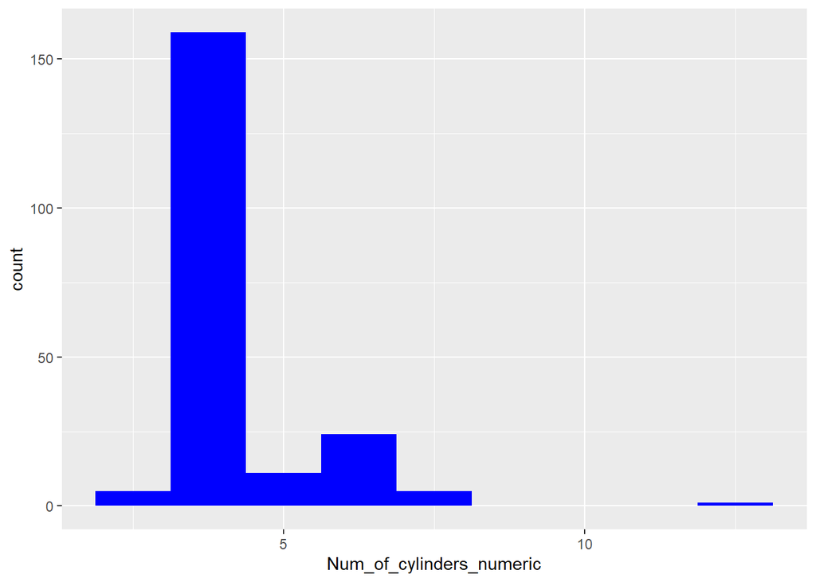

#### Densidad de vehículos según la variable número de cilindros

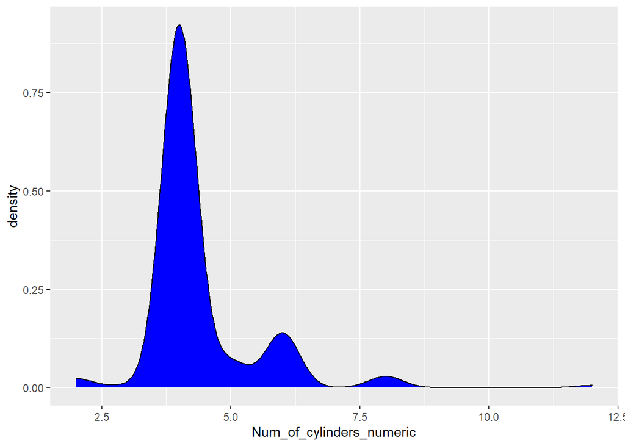

#### Histograma y Densidad de la variable número de cilindros

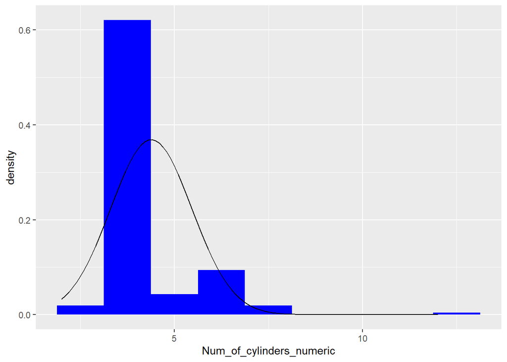

#### Resumen estadístico de la variable número de cilindros.

```
##    Min. 1st Qu.  Median    Mean 3rd Qu.    Max.
##    2.00    4.00    4.00    4.38    4.00   12.00
```

#### Histograma de la variable city-mpg (consumo en la ciudad).

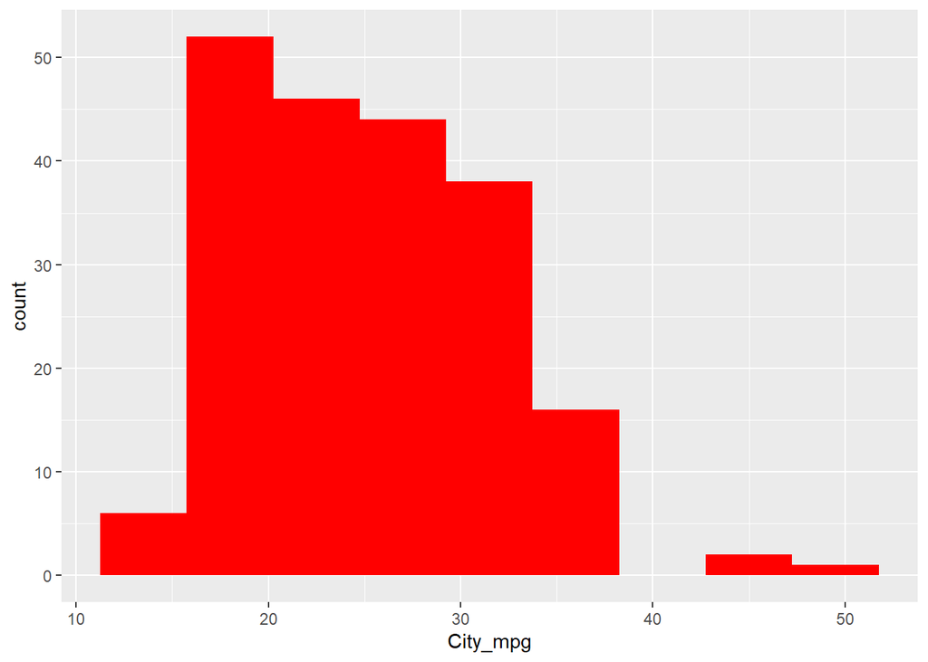

#### Densidad de vehículos según la Variable city-mpg (consumo en la ciudad).

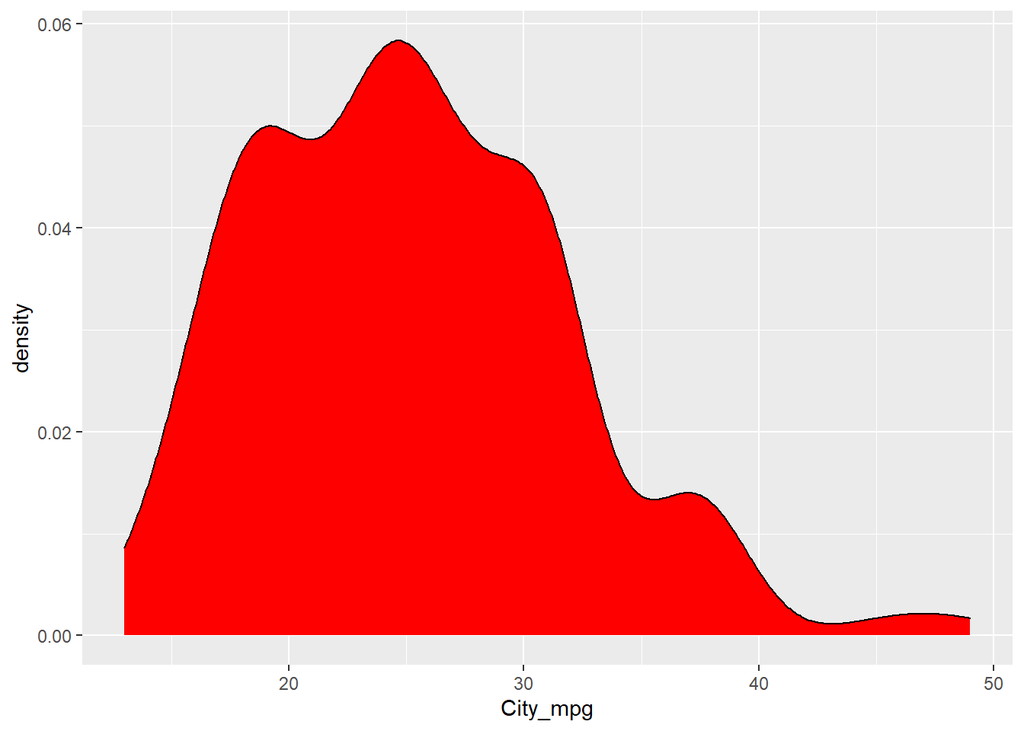

#### Histograma y Densidad de la variable city-mpg (consumo en la ciudad)

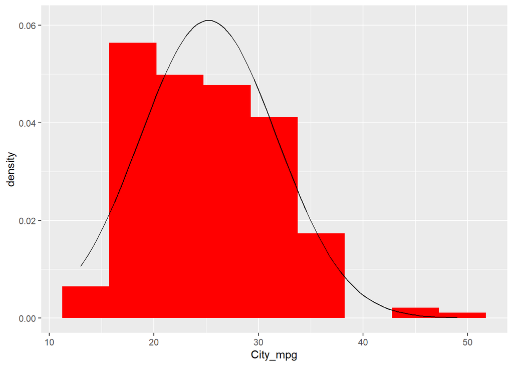

#### Diagrama de dispersión de la variable city-mpg (consumo en la ciudad) en funcion de la variable Num_of_cylinders

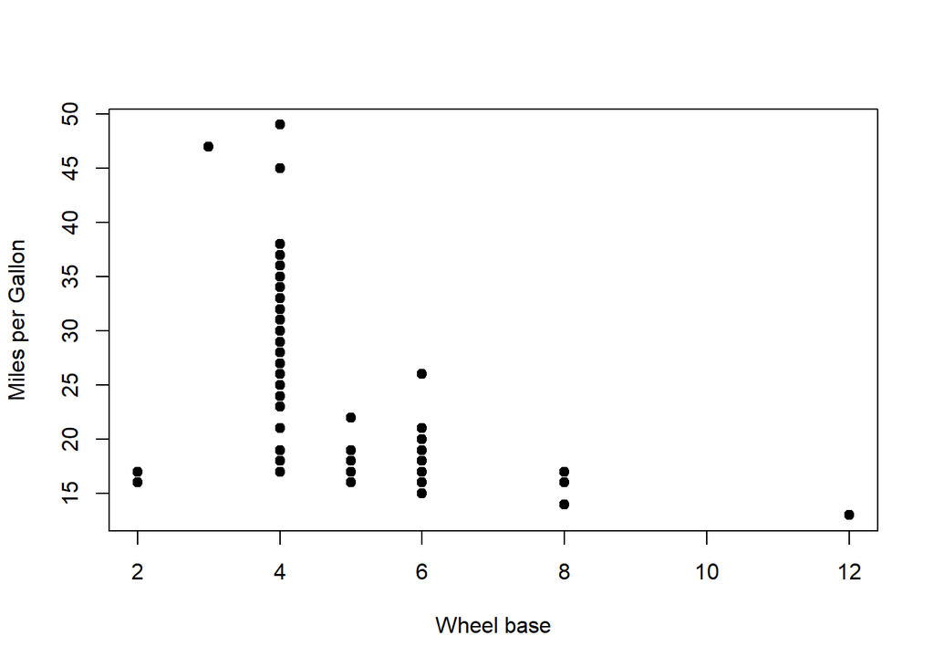

#### Ajuste lineal de City_mpg en función del Num_of_cylinders

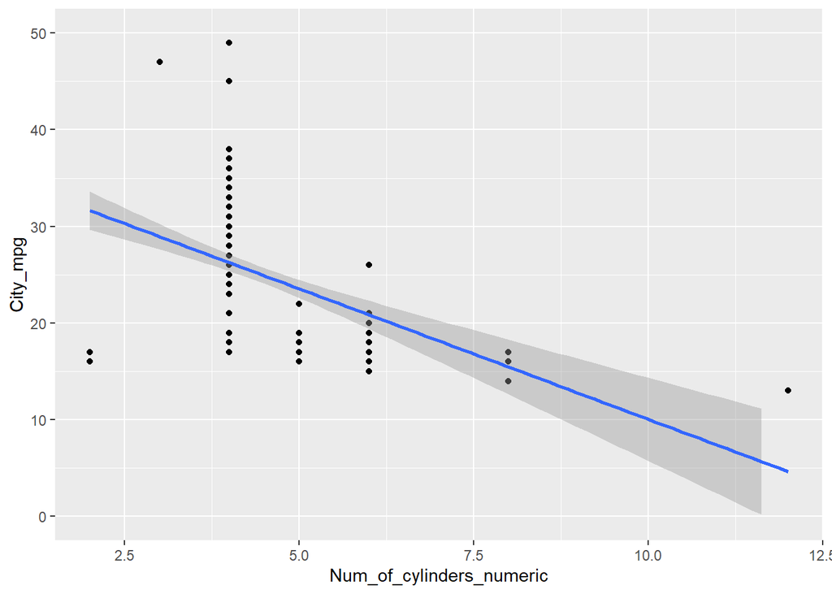

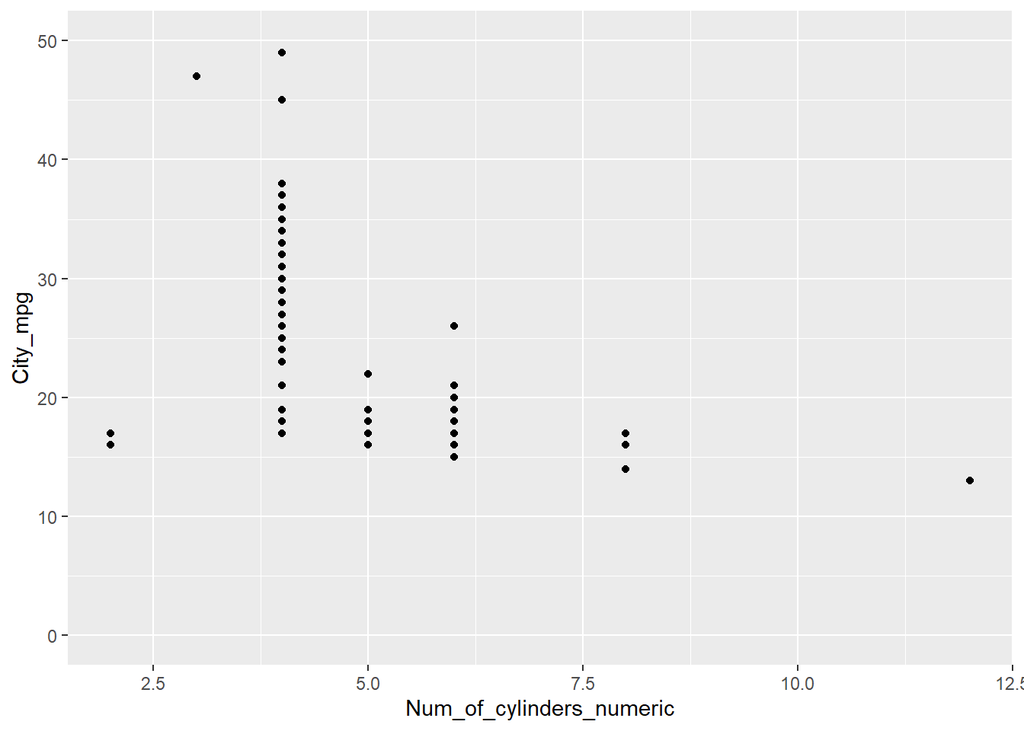

#### Histograma y Densidad de la variable City-mpg (consumo en la ciudad)

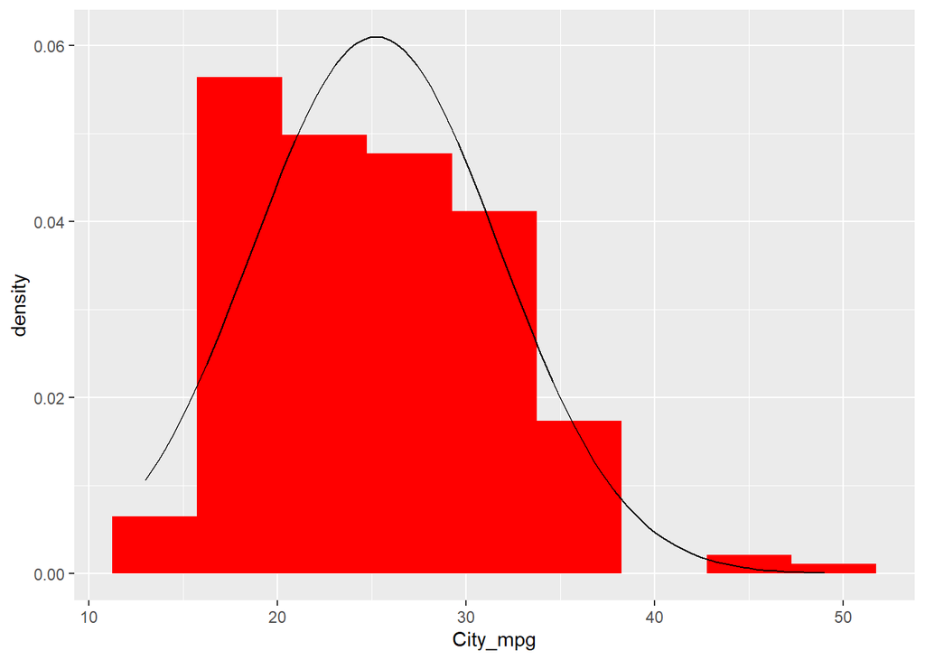

#### Resumen estadístico de la variable City-mpg (consumo en la ciudad)

```
##    Min. 1st Qu.  Median    Mean 3rd Qu.    Max.
##   13.00   19.00   24.00   25.22   30.00   49.00
```

#### Diagrama de caja de la variable City-mpg (consumo en la ciudad) en función del número de cilindros

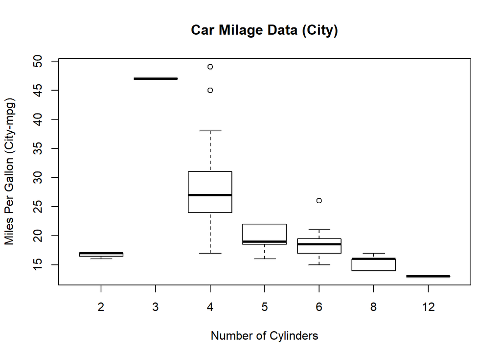

#### Diagrama de caja de la variable Highway_mpg (consumo en la carretera) en función del número de cilindros

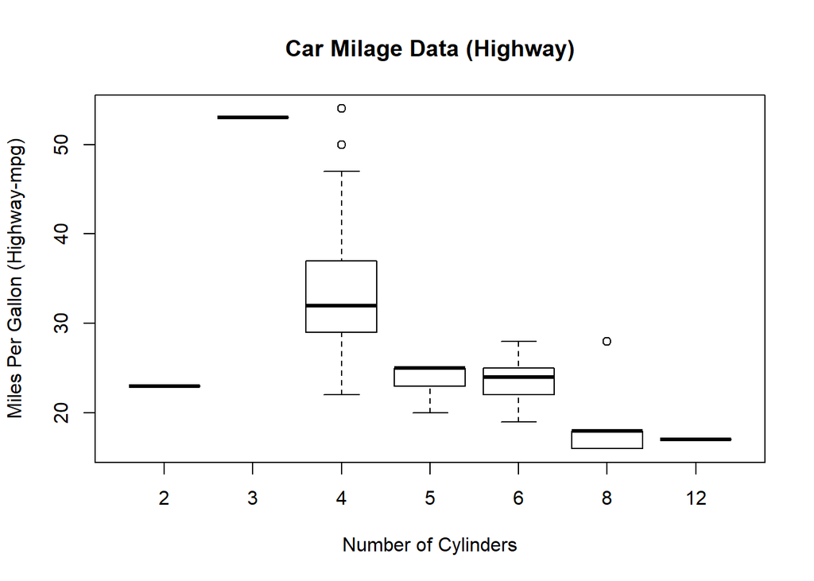

#### Tratar valores perdidos

Cambiamos los caracteres “?” por “NA” en dataframe

```r
dfvehiculos$Bore[dfvehiculos$Bore == "?"] <- "NA"
dfvehiculos$Stroke[dfvehiculos$Stroke == "?"] <-"NA"
dfvehiculos$Horsepower[dfvehiculos$Horsepower == "?"] <- "NA"
dfvehiculos$Peak_rpm[dfvehiculos$Peak_rpm == "?"] <- "NA"
dfvehiculos$Price[dfvehiculos$Price == "?"] <- "NA"
dfvehiculos$Num_of_doors[dfvehiculos$Num_of_doors == "?"] <- "NA"
dfvehiculos$Normalized_losses[dfvehiculos$Normalized_losses == "?"] <- "NA"
dfvehiculos <- na.omit(dfvehiculos)
```

#### Transformaciones necesarias.

Realizamos las transformaciones para que las varibles que tengan que ser numéricas, sean numéricas y no factores.

```r
dfvehiculos$Bore = as.numeric(dfvehiculos$Bore)
dfvehiculos$Stroke = as.numeric(dfvehiculos$Stroke)
dfvehiculos$Horsepower = as.numeric(dfvehiculos$Horsepower)
dfvehiculos$Peak_rpm = as.numeric(dfvehiculos$Peak_rpm)
dfvehiculos$Price = as.numeric(dfvehiculos$Price)
#str(dfvehiculos)
```

### Identifique otros factores que puedan influir sobre el consumo del vehículo.

#### Análisis explotatorio de influencia de las variables númericas en City_mpg

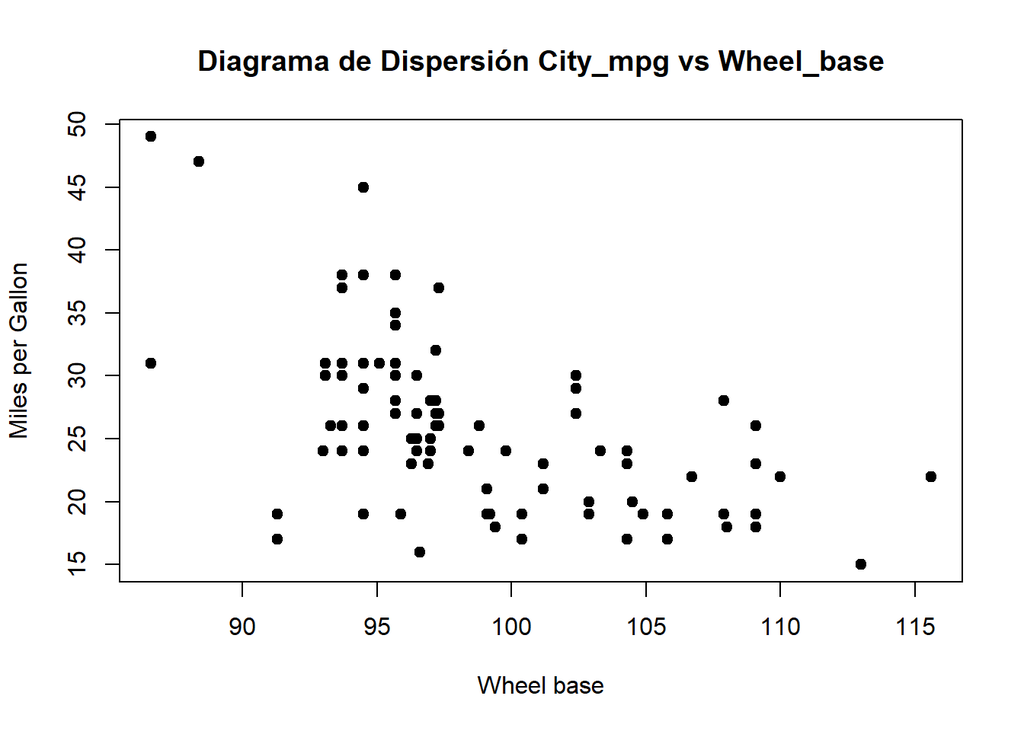

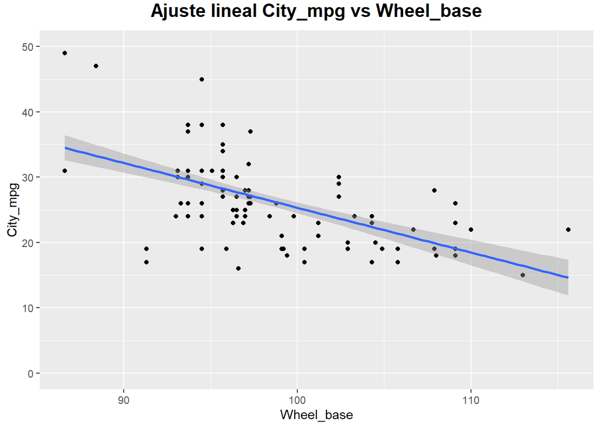

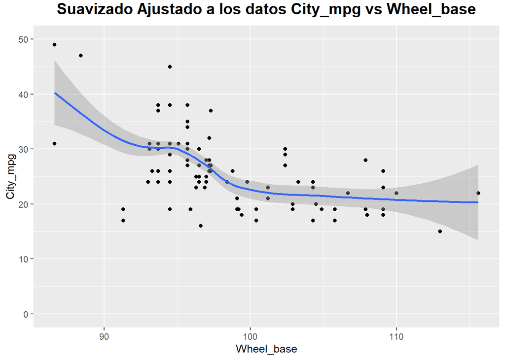

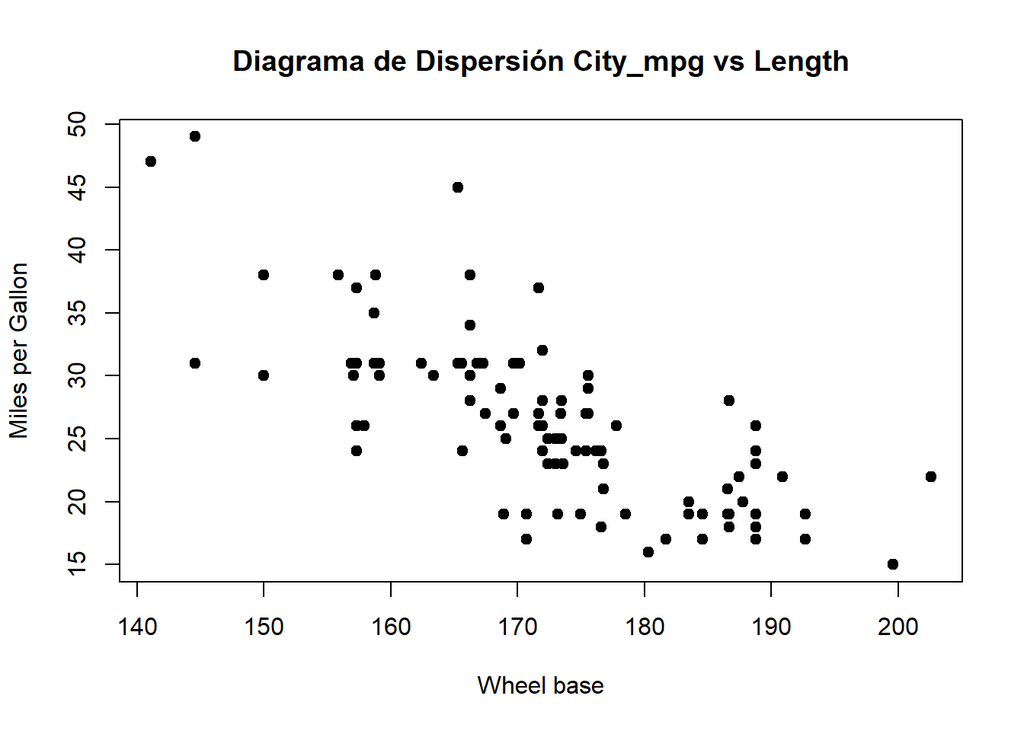

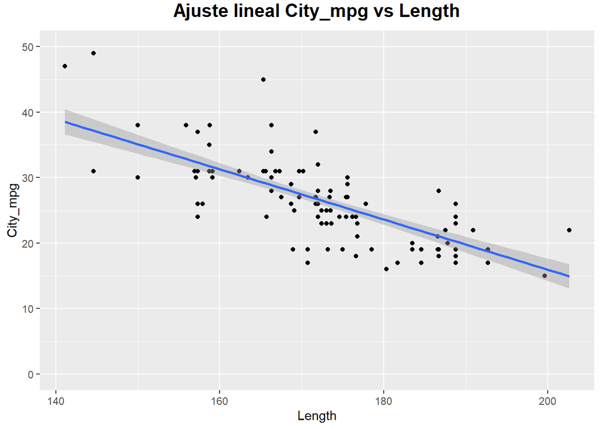

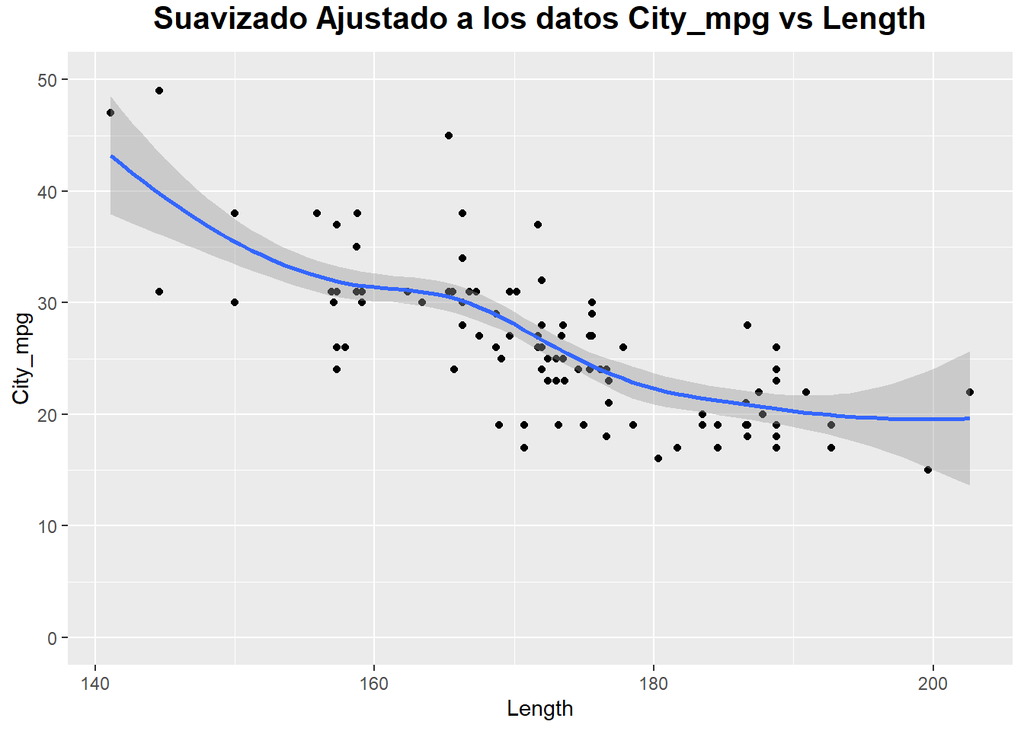

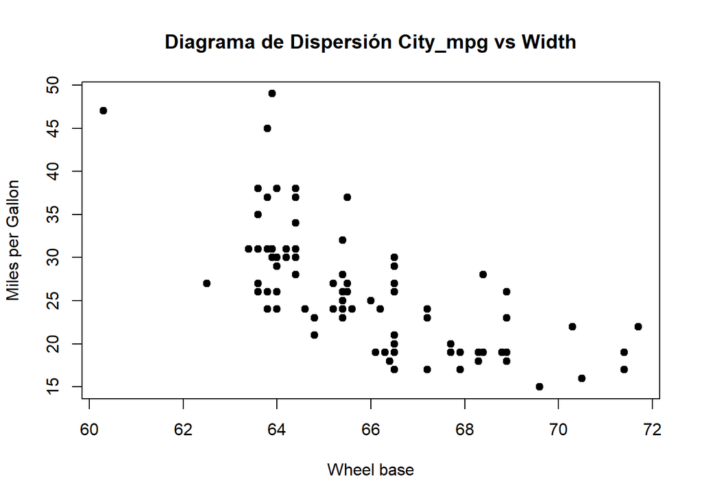

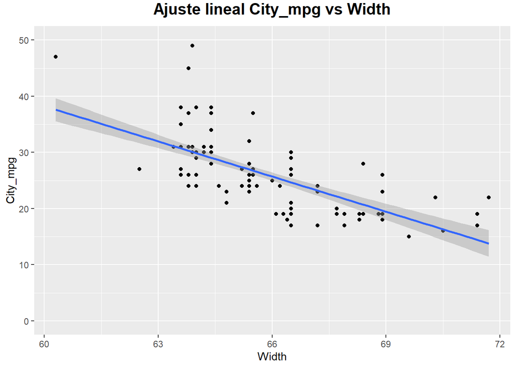

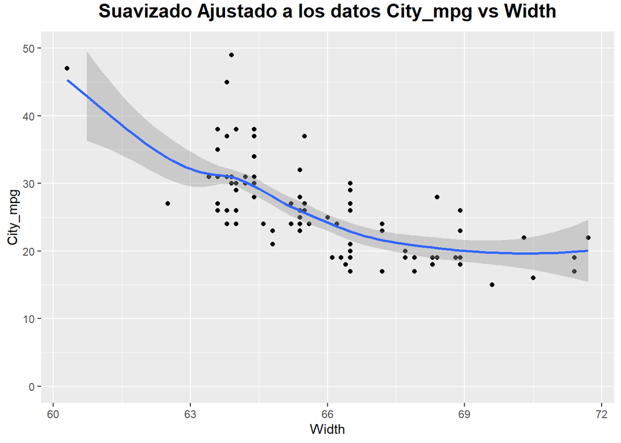

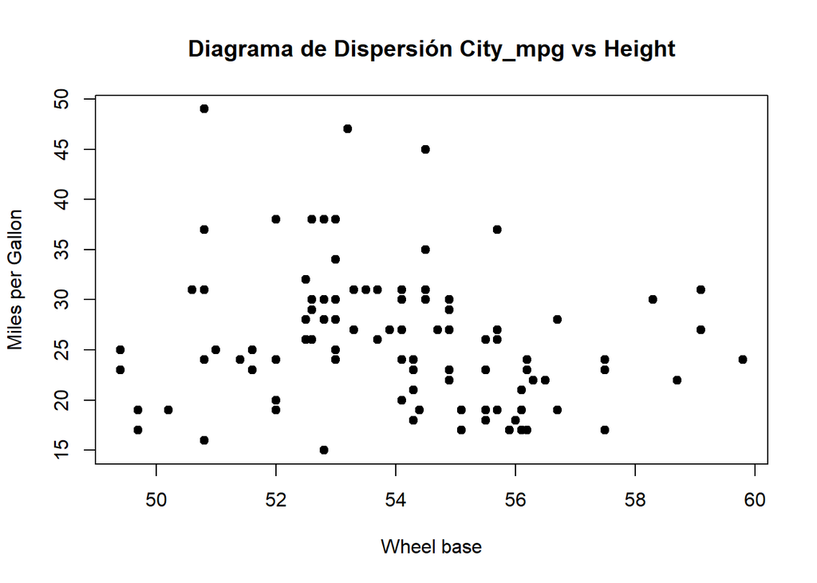

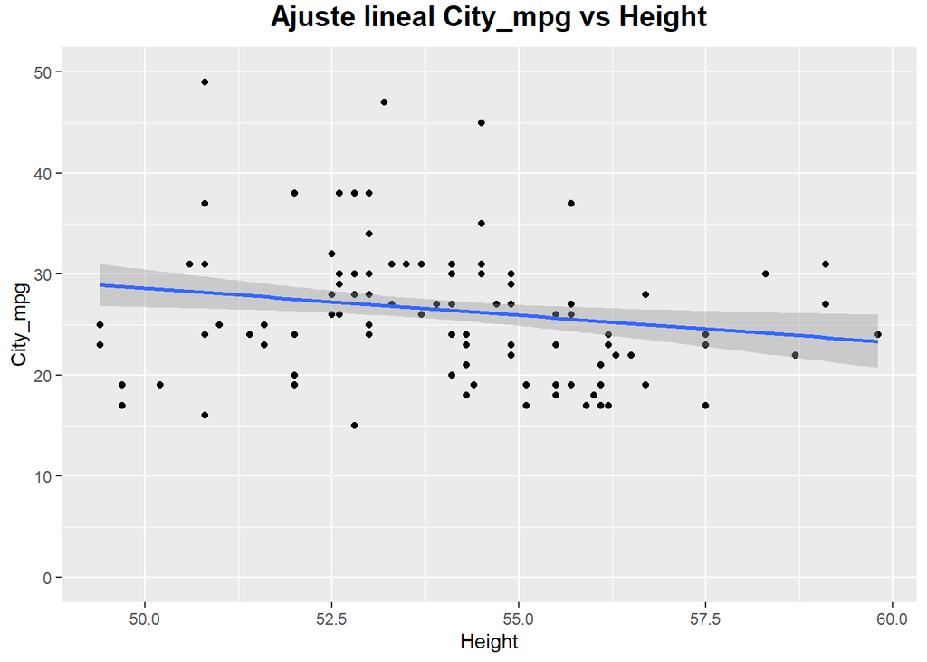

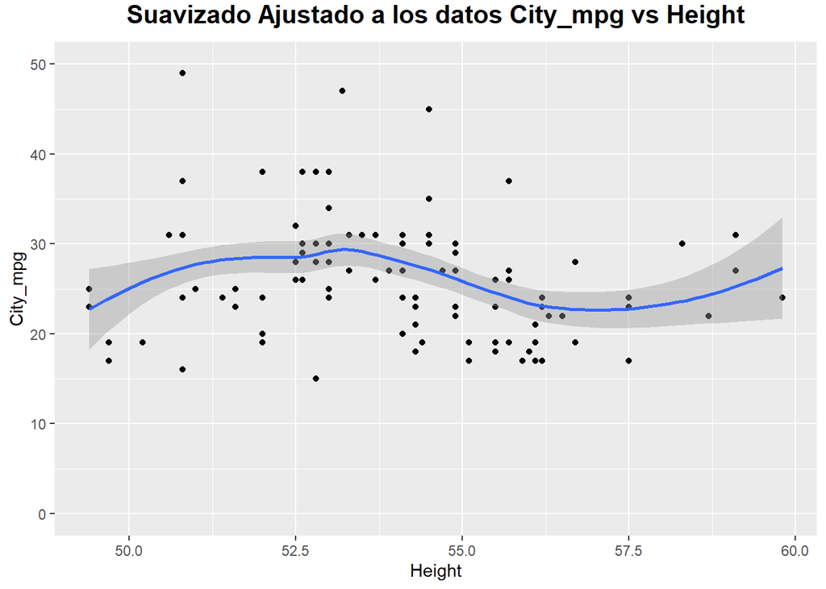

[30 more figures not shown]

### Análisis explotatorio de influencia de las variables nominales en City_mpg

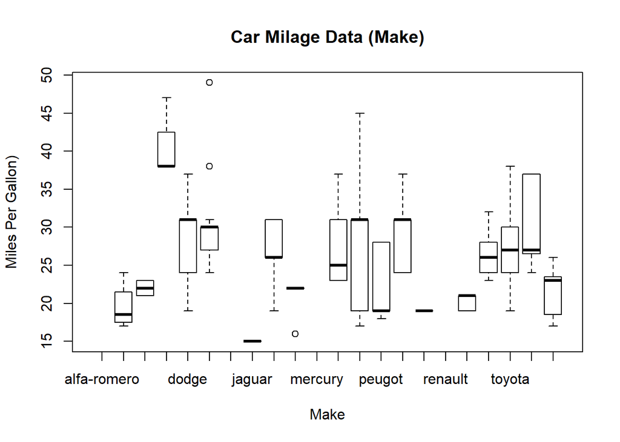

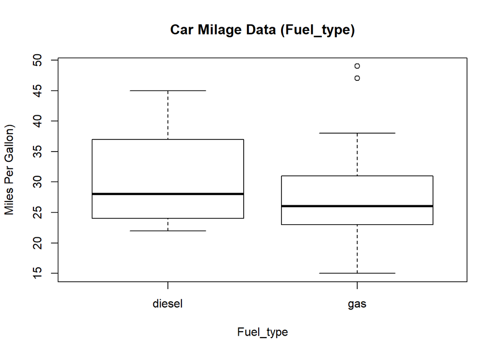

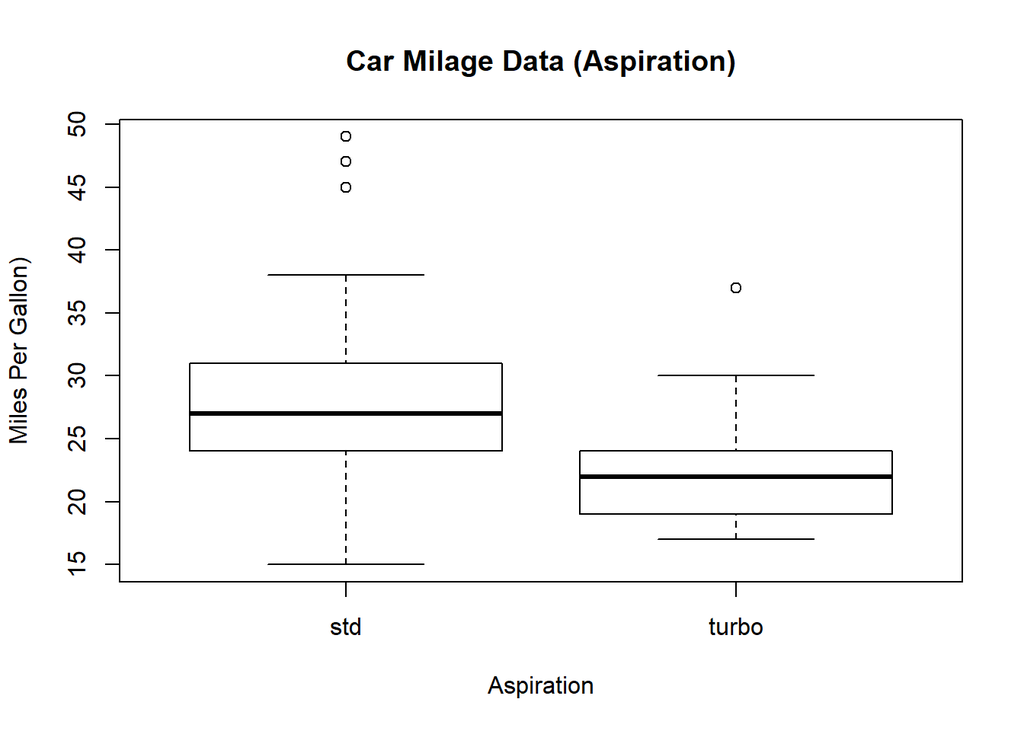

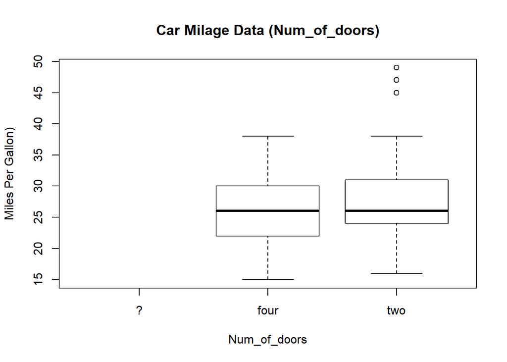

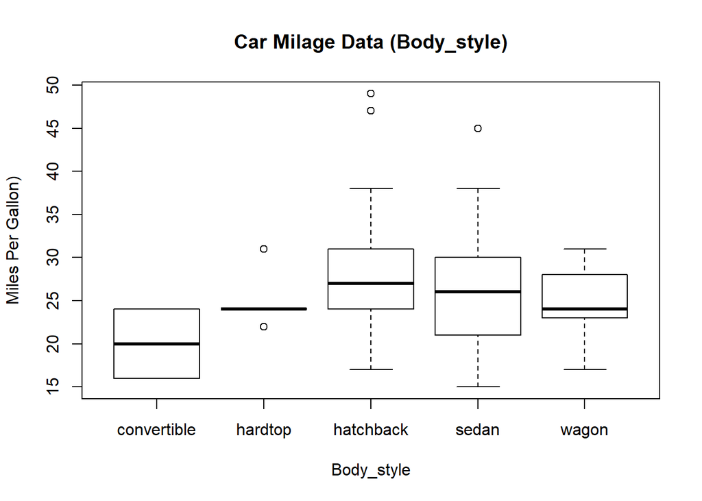